# DAB501 - Project #1 - Data Visualization

Transit_Cost

Name and ID of the Presenters:

1. **Anjana Padikkal Veetil** **ID- 0780343**
2. **Rahul Dalal** **ID- 0780440**
3. **Saharsh Sinha** **ID- 0783417**
4. **Rohit Rohit** **ID- 0773987**
5. **Prathap David Carlo** **ID- 0787017**

**Group Number: 21**

This is to confirm you that this project is completed by above mentioned group members and have adhered to **St. Clair College’s Academic Integrity policies** in completing this project.

The versions of R and RStudio used for this project are as below. R versions: R version 4.0.5 (2021-03-31) Rstudio versions: 1.4.1106  
A list of R packages used for this project and their versions are as below.

1.tidyvesre Version: 1.3.1 The ‘tidyverse’ is a set of packages that work in harmony because they share common data representations and ‘API’ design  
2. Readr Version: 1.4.0 The key problem that readr solves is parsing a flat file into a tibble  
3 janitor Version: 2.1.0 Simple Tools for Examining and Cleaning Dirty Data  
4.ggplot2 Version: 3.3.3 Create Elegant Data Visualisations Using the Grammar of Graphics  
5. gganimate Version: 1.0.7  
The grammar of graphics as implemented in the ‘ggplot2’ package has been successful in providing a powerful API for creating static visualization. In order to extend the API for animated graphics this package provides a completely new set of grammar, fully compatible with ‘ggplot2’ for specifying transitions and animations in a flexible and extensible way.

Documentation of the data sets:

Attribution of the owner/creator of the data **Data owner** https://github.com/jthomasmock

Links to the data Get the data here https://github.com/rfordatascience/tidytuesday/blob/master/data/2021/2021-01-05/readme.md

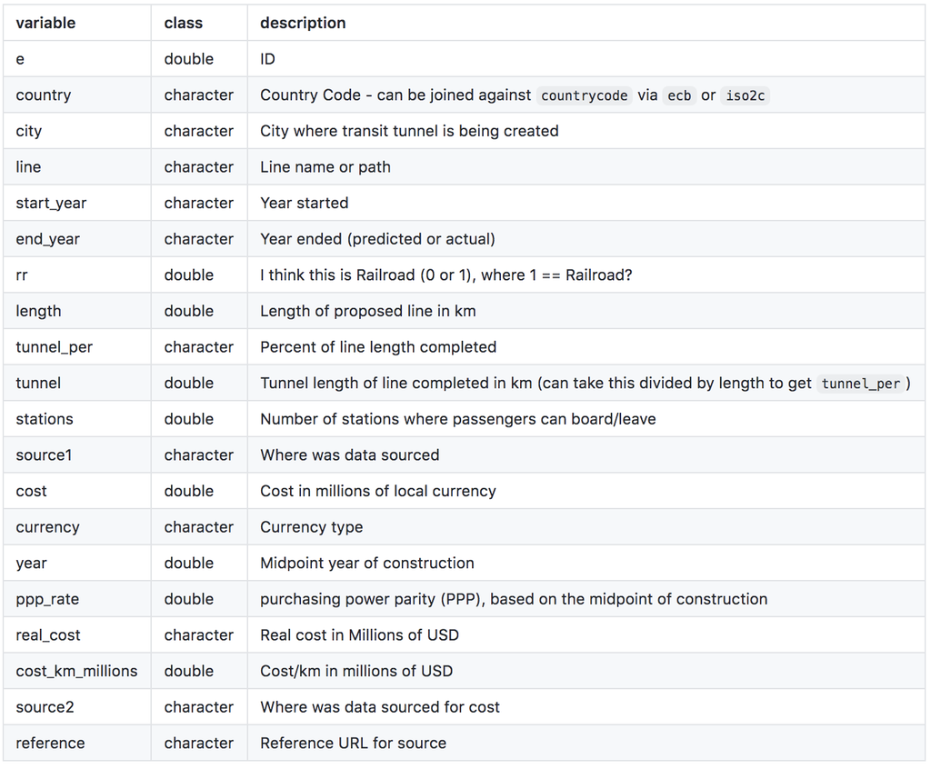

**Notes on the data:** Costs include all construction and construction-related expenditures, but not rolling stock or sales taxes. In some cases, rolling stock costs are included in the headline numbers, and we have tried to subtract them whenever possible; in some remaining cases, it was not possible, and we note that the costs include the equipment.

- Costs are adjusted for purchasing power parity (PPP), based on the midpoint of construction. This adjustment is imperfect in countries with rapid changes in the PPP rate due to high inflation, typically in the developing world. Of note, we have not adjusted for inflation so far; since all costs are converted to US dollars, you can inflation-adjust using American inflation rates.
- The length of a project includes length in service, excluding non-revenue tracks toward railyards and tail tracks; for example, our length for the 7 extensions in New York starts at Times Square and ends at 34th Street and 11th Avenue, even though storage tracks extend south to 26th Street.
- The source column describes what type of source we used. Often, we used different sources for length and cost, since costs can run over and therefore, we’ve attempted to use the most recent sources possible, whereas length is fixed for the duration of the project.
1. Wiki means Wikipedia; it is not an acceptable source for costs, only length and opening year.
2. Measured means we measured the length (including tunnel length) on satellite photos or mapping software like Google Earth or Open Railway Map.
3. Media means general media.
4. Trade means trade publications, like Railway Gazette and International Rail Journal.
5. Plan means official plans, whether by the relevant agency, the state, the World Bank, etc.

### About Transit-infrastructure project data set:

Transit-infrastructure project database that spans more than 50 countries and totals more than 11,000 km of urban rail built since the late 1990s. The goal of this dataset is to figure out how to deliver more high-capacity transit projects for a fraction of the cost in countries like the United States.

### Purpose of this project:

The main purpose of this project is to visualize subsets of the data to help the reader better understand the nature of the variables presented. We have considered not to make any changes to the original data, however we have done quite a few sub-setting and used some functions to get the particular data that we wanted to visualize and get insights from them. All these steps are well explained along with the flow of the project. This project brings out the presentation to nature of different variables of the data set using 9 different graphs with the help of ggplot2 package.

#### Packages loaded

```r
library(tidyverse)
library(readr)
library(janitor)
library(gganimate)
```

#### Transit cost is the data set taken from the mentioned link

```r
transit_cost <- readr::read_csv('https://raw.githubusercontent.com/rfordatascience/tidytuesday/master/data/2021/2021-01-05/transit_cost.csv')
```

#### Cleaning code-Provided By the Creators.

```r
transit_cost <-transit_cost %>%
  mutate(start_year = as.integer(start_year),
         end_year = as.integer(end_year),
         tunnel_per = parse_number(tunnel_per)/100,
         real_cost = as.numeric(real_cost))

raw_df <- transit_cost %>%
  janitor::clean_names() %>%
  filter(real_cost != "MAX")

raw_df %>%
  arrange(desc(cost_km_millions))
```

| e | country | city | line | start_year | end_year | rr | length | tunnel_per | tunnel | stations | source1 | cost | currency | year | ppp_rate | real_cost | cost_km_millions | source2 | reference |
| --- | --- | --- | --- | --- | --- | --- | --- | --- | --- | --- | --- | --- | --- | --- | --- | --- | --- | --- | --- |
| 7411 | US | New York | East Side Access | 2007 | 2022 | 1 | 2.800 | 1.0000 | 2.8000 | 1 | Measured | 11000.00 | USD | 2015 | 1.0000000 | 11000.000 | 3928.57143 | Media | https://www.nytimes.com/2018/04/25/nyregion/mta-east-side-access-11-billion.html |
| 7410 | US | New York | Second Avenue Phase 2 | 2019 | 2029 | 0 | 2.600 | 1.0000 | 2.6000 | 3 | Measured | 6390.00 | USD | 2024 | 1.0000000 | 6390.000 | 2457.69231 | Plan | https://www.transit.dot.gov/sites/fta.dot.gov/files/2020-07/FY21-Annual-Report-on-Funding-Recommendations.pdf |
| 7416 | US | New York | Gateway | 2019 | 2026 | 1 | 5.300 | 1.0000 | 5.3000 | 0 | Measured | 9500.00 | USD | 2023 | 1.0000000 | 9500.000 | 1792.45283 | Plan | https://www.masstransitmag.com/rail/infrastructure/press-release/21094267/gateway-program-the-hudson-tunnel-projects-trims-14-billion-with-new-financial-plan |
| 7409 | US | New York | Second Avenue Phase 1 | 2007 | 2016 | 0 | 2.700 | 1.0000 | 2.7000 | 3 | Measured | 4450.00 | USD | 2012 | 1.0000000 | 4450.000 | 1648.14815 | Media | https://www.nytimes.com/2016/12/19/nyregion/second-avenue-subway-opening.html |
| 7408 | US | New York | 7 extension | 2007 | 2014 | 0 | 1.600 | 1.0000 | 1.6000 | 1 | Measured | 2400.00 | USD | 2011 | 1.0000000 | 2400.000 | 1500.00000 | Plan | http://web.mta.info/nyct/service/new7LineExtension_to11Avenue.htm |
| 7329 | SG | Singapore | Circle Line Stage 6 | 2017 | 2025 | 0 | 4.000 | 1.0000 | 4.0000 | 3 | Media | 4850.00 | SGD | 2021 | 1.1300000 | 5480.500 | 1370.12500 | Media | https://www.straitstimes.com/singapore/transport/last-stage-of-circle-line-to-cost-a-lot-more-than-first-5-stages |
| 7417 | UK | London | Crossrail | 2009 | 2021 | 1 | 21.000 | 1.0000 | 21.0000 | 8 | Measured | 13328.00 | GBP | 2015 | 1.4000000 | 18659.200 | 888.53333 | FOI | NA |
| 7152 | US | Los Angeles | Purple Phase 3 | 2020 | 2027 | 0 | 4.200 | 1.0000 | 4.2000 | 2 | Media | 3600.00 | USD | 2023 | 1.0000000 | 3600.000 | 857.14286 | Media | https://la.streetsblog.org/2020/03/24/metro-signs-1-3-billion-full-funding-grant-agreement-for-westside-subway-phase-3/ |
| 7435 | NZ | Auckland | City Rail Link | 2013 | 2024 | 1 | 3.500 | 1.0000 | 3.5000 | 4 | Wiki | 4419.00 | NZD | 2018 | 0.6770000 | 2991.663 | 854.76086 | Plan | https://ourauckland.aucklandcouncil.govt.nz/articles/news/2019/04/revised-cost-for-city-rail-link/ |
| 7280 | AU | Melbourne | Metro Tunnel | 2018 | 2025 | 0 | 9.000 | 1.0000 | 9.0000 | 5 | Plan | 11000.00 | AUD | 2021 | 0.6900000 | 7590.000 | 843.33333 | Plan | https://metrotunnel.vic.gov.au/about-the-project/faq |

[output cut: 527 more lines]

*We have used the variables end_year and start_year to calculate the total time taken by the project to complete as a variable -Project_time.*

```r
Project_time <- (raw_df$end_year) - (raw_df$start_year)
raw_df$project_time <- Project_time
```

*We have used ggplot2 package for plotting and used histogram geometry for our continious variable *project_time* which is on the x-axis. binwidth has been assigned to 0.5, color is bisque3 and also changed the scale of x-axis via. scale_x_continuous function, in which breaks are being used with the gap of 1 from range(1,30), so that our plot can be easily interpreted. Furthermore, in the next layer we have added stat_bin function so that we can show particular counts of projects in a time- period. Finally, a minimal theme has been added to the plot*

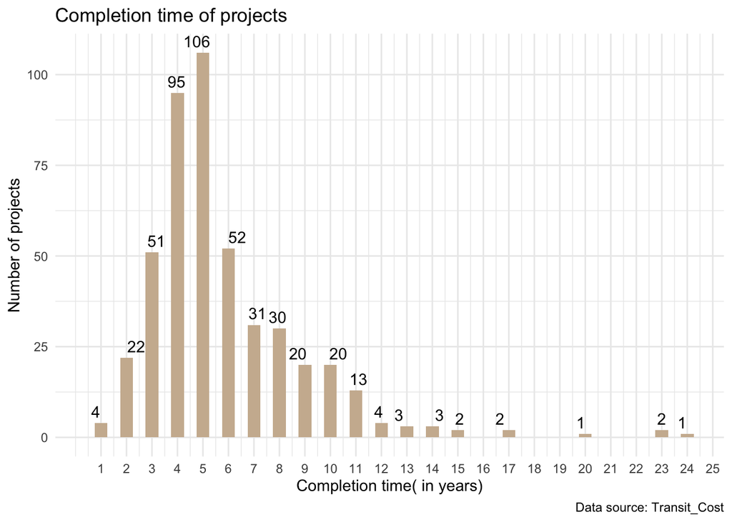

```r
projects <- ggplot(raw_df,aes(project_time))+
  geom_histogram(binwidth = 0.5, fill = 'bisque3')

projects <- projects + labs(title = 'Completion time of projects', x = 'Completion time( in years)', y = 'Number of projects', caption = "Data source: Transit_Cost") +
  scale_x_continuous(breaks = seq(1, 30, by = 1))+
   stat_bin(aes(y=..count..,label=ifelse(..count..==0,"",..count..)), geom="text", vjust=-.5)+
  theme_minimal()
projects
```

*Here, we create a boxplot for cost_km_millions continuous variable with the help of boxplot geometry in ggplot2 package, then changed the scale of x_axis via. scale_x_continuous function, in which breaks are being used with the gap of 250 from range(0,4000).Finally, by using theme, in which we have defined y_axis as its density. And used title in the labs function.*

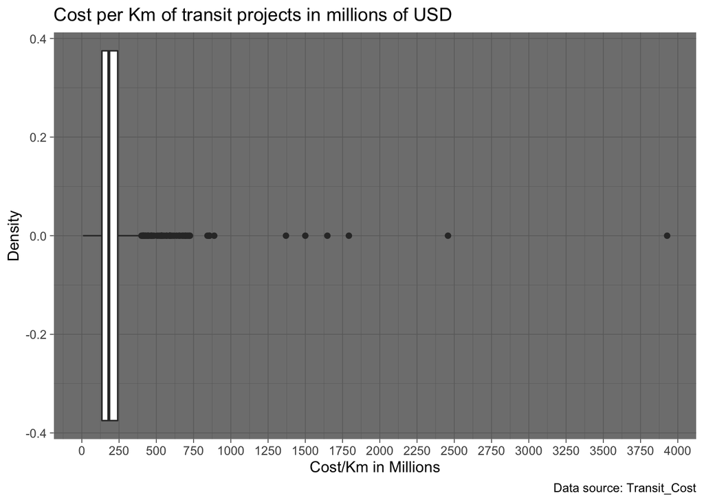

```r
ggplot(raw_df,aes(cost_km_millions))+
  geom_boxplot()+
  scale_x_continuous(breaks = seq(0, 4000, by = 250))+
  labs(title = 'Cost per Km of transit projects in millions of USD', x = 'Cost/Km in Millions',y= "Density", caption = "Data source: Transit_Cost")+
  theme_dark()
```

**The above box plot has been created, for analyzing the Cost/km of transit projects in millions of USD ( cost_km_millions). We can see that 50 percentile projects’ cost is from 125 to 250. Approximately 75 % of the cost of the project is under 250 million per km. In addition, 6 projects cost higher than 1250 million per km. Out of them, one project cost is around 4000 million/km.**

*Since we want to plot for categorical variable, We use bar_geometry in ggplot2 package and defined aesthetics under geom_bar() which is country on x-axis and also assigned country to color also. By assigning country to color, every country will be shown in different colors that helps to visualize clearly.Further, we have defined the width of bar is 0.8 and then used coord_flip(), so that our x-axis and y-axis interchanged positions.Finally, we have use labs() for labeling.In theme, we have also defined y text size, so that it can clearly visualize.*

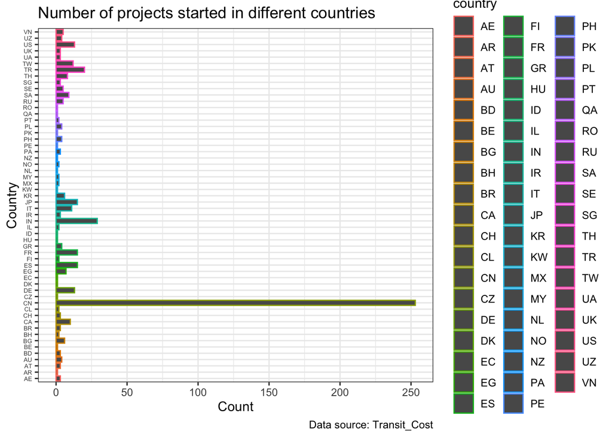

```r
ggplot(raw_df)+
  geom_bar(aes(country,  color = country), width=0.8)+
  coord_flip()+
  labs(title = 'Number of projects started in different countries', x = 'Country', y = 'Count',caption = "Data source: Transit_Cost")+
  theme_bw()+
  theme(axis.text.y = element_text(size = 5))
```

**It can be seen that CN-China is the only country in which more than 250 Transit_projects’ started while, approximately 25 projects accounted for ‘IN’ Country. All other countries’ projects figure is less than 25.**

*Filtering Countries and subsetting China*

```r
country_CN <-raw_df %>%
  filter(country == 'CN')
```

*The code below is similar to earlier one, Only here we have assigned city variable to label in bar_geometery and also filled bars with ‘firebrick4’ color. The theme used here is black and white i.e theme_bw()*

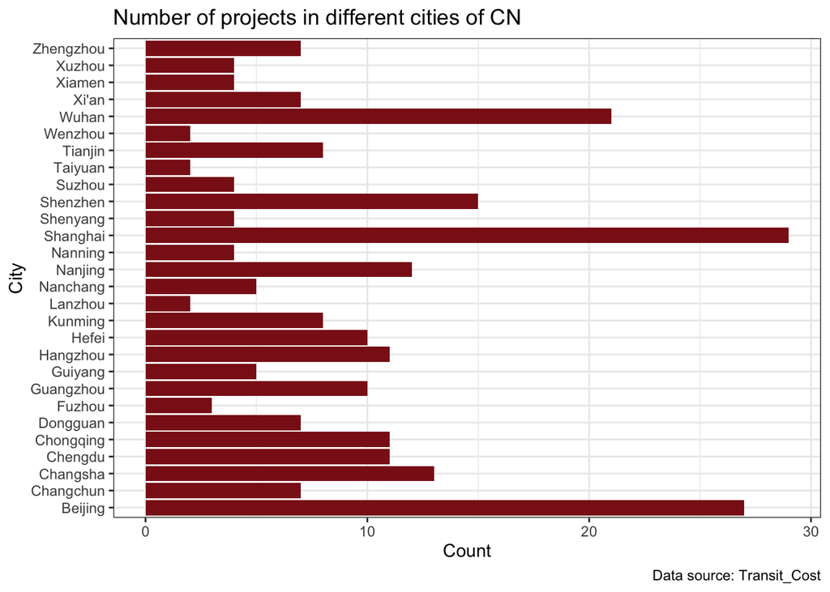

```r
ggplot(country_CN)+
  geom_bar(aes(city,label = city),fill = 'firebrick4')+
  labs(title = 'Number of projects in different cities of CN', x = 'City', y = 'Count',caption = "Data source: Transit_Cost")+
  coord_flip()+
  theme_bw()
```

*Creating Country List to filter out top 10 countries with highest number of projects. From the transit data set, all the projects that are completed are filttered by filtering the end_year upto 2020. The number of projects in different countries are counted from the filtered data set and top 10 countries are taken and stored in country_list.*

```r
country_list <-  raw_df %>%
  filter(end_year <= 2020) %>%
  count(country)%>%
  top_n(10) %>%
  pull(country)
```

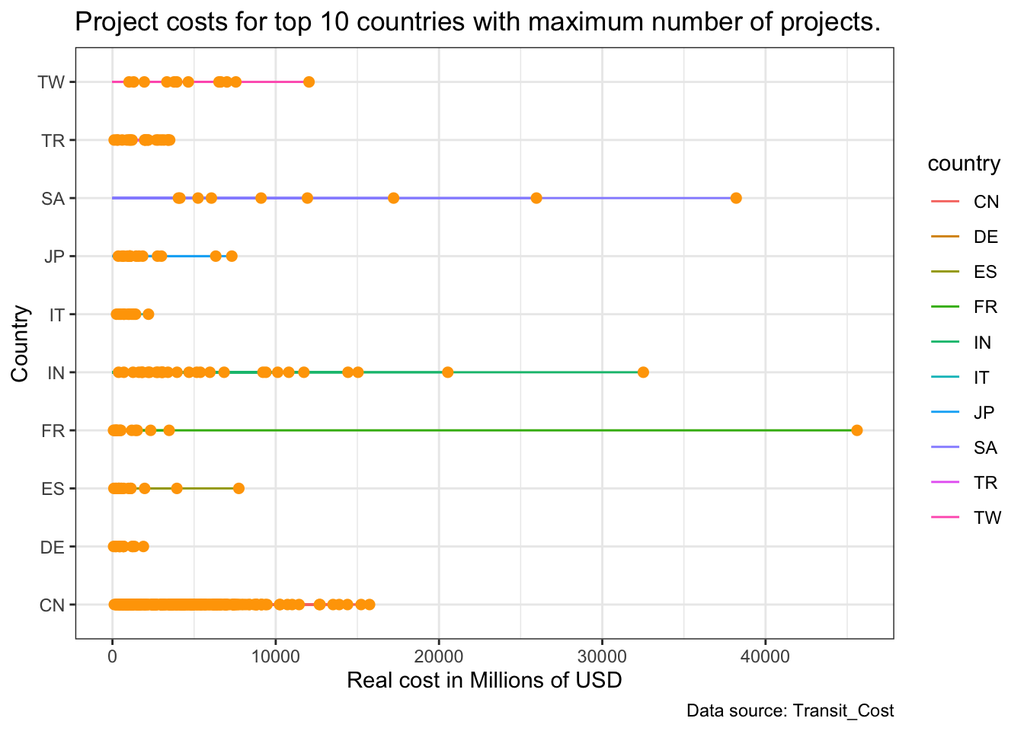

```r
raw_df %>%
  filter(country %in% country_list) %>%
  ggplot(aes(country, real_cost, colour = country)) +
  geom_segment(aes(xend=country, yend=0))+
  geom_point( size=2, color="orange") +
  coord_flip() +
  theme_bw() +
  xlab("")+
  labs(title = "Project costs for top 10 countries with maximum number of projects.",
       x = "Country",
       y = "Real cost in Millions of USD",caption = "Data source: Transit_Cost")
```

*Using ggplot globally defined the aes x-axis as length, y-axis as real_cost, assigned colour to stations and size to tunnel. Added geom_point layer as well as geom_smooth layer for better understanding of the trend.*

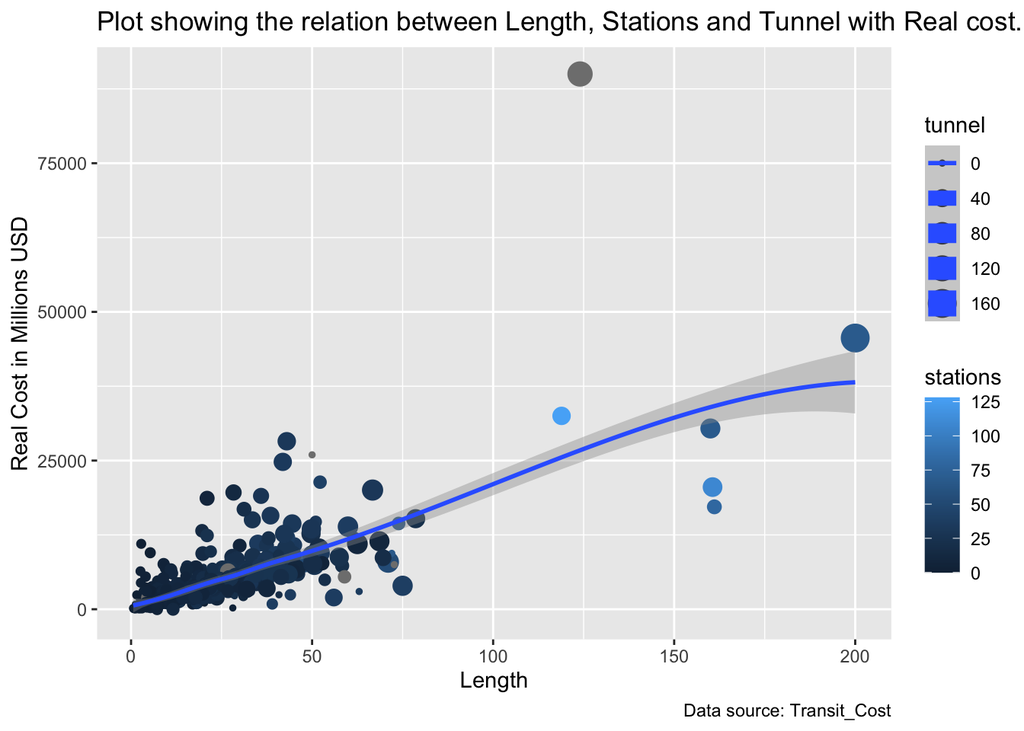

```r
raw_df %>%
  ggplot(aes(x=length,y=real_cost,colour=stations,size=tunnel,na.rm=TRUE))+
  geom_point()+
  geom_smooth()+
  labs(title = "Plot showing the relation between Length, Stations and Tunnel with Real cost.",
       x = 'Length',
       y = 'Real Cost in Millions USD',caption = "Data source: Transit_Cost")
```

*Filtered the dataset taking only the top 10 countries with maximum number of projects. Defined the aes globally with x-axis as cost and y-axis as real cost and assigned colour to PPP_rate then added geom_point layer. Rescaled the x and y axis using xlim and ylim.*

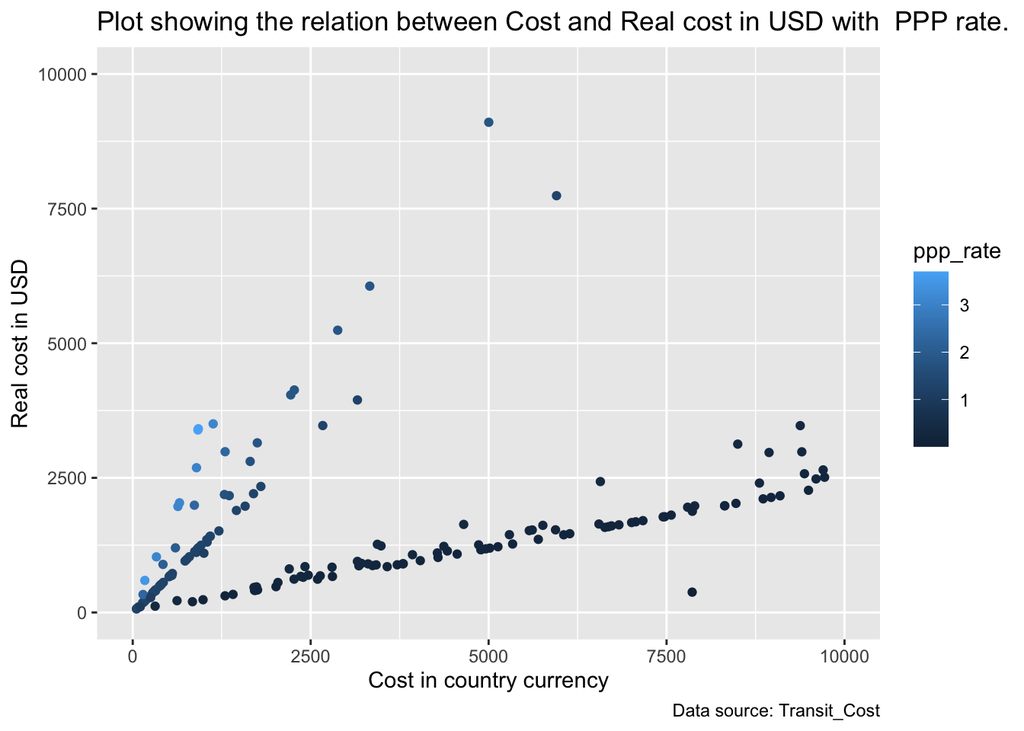

```r
raw_df %>%
  filter(country %in% country_list) %>%
  ggplot(aes(x=cost,y=real_cost,colour=ppp_rate))+
  geom_point()+
  xlim(0,10000)+
  ylim(0,10000)+
  labs(title = "Plot showing the relation between Cost and Real cost in USD with  PPP rate.",
       x = 'Cost in country currency',
       y = 'Real cost in USD',caption = "Data source: Transit_Cost")
```

**The plot shows the relation between cost, PPP rate and real cost.We can see that countries with higher PPP rate have real cost more than the cost in their currency whereas, countries with less PPP rate has real cost less than their currency cost.**

*From the dataset ‘CN’ - China is filltered out from the list of countries and stored in Country_China as it has highest number of Projects*

```r
Country_China <- raw_df %>%
filter(country == "CN")
```

```r
China_cities <- Country_China %>%
filter(city %in% c("Xi'an", "Wuhan", "Shanghai","Beijing", "Shenzhen","Changsha"))
```

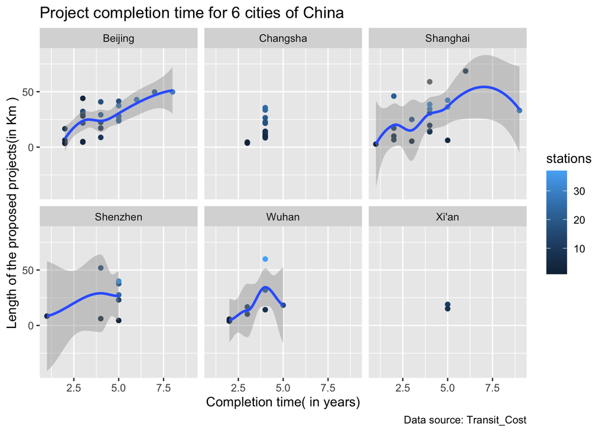

```r
Completion_data <- ggplot( data = China_cities) +
  geom_point(mapping = aes(project_time,length,colour=stations)) +
  geom_smooth(mapping = aes(project_time,length))+
  facet_wrap( ~city)
Completion_data <- Completion_data +
  labs(title = 'Project completion time for 6 cities of China', x = 'Completion time( in years)',y ='Length of the proposed projects(in Km )',caption = "Data source: Transit_Cost")

Completion_data
```

*Considering top 6 countries.*

```r
country_list_six <- transit_cost %>%
  count(country)%>%
  top_n(6) %>% pull(country)
```

*The code contains a plot of a list of countries in country_plot by filtering the data set (transit_cost) concerning the list of top 6 countries. We use ggplot and map x to end_ year, y to real_cost and provide colour to the country. By doing this we can get a timeline of each project completion and the real cost associated with it. We choose to add aesthetics geom_point and facet_wrap as we have the top 6 countries.*

```r
country_plot<- transit_cost %>%
  filter(country %in% country_list_six) %>%
  ggplot(aes(x= end_year, y= real_cost, color=country)) +
    geom_point()+ facet_wrap(~country, nrow=3)+
    labs(title = "Real cost by end of the project of top 6 countries" , subtitle = "Data also contains maximum number of completed Projects",
       x = 'End year(year)',
       y = 'Real cost in USD',
       caption = "Data source: Transit_Cost")
```

*Animating the plot by taking top 6 countries.*

[figure not shown]

```r
animate_plot <- country_plot + geom_point(aes(group = seq_along(year))) +   transition_reveal(year)
animate_plot
```

**Contribution by Team Members**

**Anjana Padikkal Veetil**  
Completed- One plot displaying information about both a continuous variable and a categorical variable. Two plots should display information that shows a relationship between two variables. Code review and edit

**Prathap David Carlo**  
Completed - one plot should use faceting and display information about 4 variables. Provided the layout of the Rmd File( Introduction framework).Code review and edit

**Rahul Dalal**  
Helped accross project research and contributed in the 4 variable faceting plot. Code review and edit

**Saharsh Sinha**  
Competition plot -animation (gganimate) Plot, Inclusion and editing the Project file. Wrote answers to the summary questions. Code review and edit.

**Rohit Rohit**  
Completed two plots displaying the distribution of a single continuous variable. Two plots displaying information about a single categorical variable.Code review and edit

### References to any external sources used:

We have analysed the codes from the below references and examined on what context they are used & what are all the functions supported those codes. With those details, it was helpful for us to build this project

http://www.cookbook-r.com/Graphs/

http://r-statistics.co/Top50-Ggplot2-Visualizations-MasterList-R-Code.html

http://www.cookbook-r.com/Graphs/Scatterplots_(ggplot2)/

**Answers to questions**

**-In what ways do you think data visualization is important to understanding a data set?**

Data visualization is important in understanding data set in following ways: The primary objective of data visualization is to provide exploratory data analysis of the dataset to get useful insights and communicate the findings that could be understood better by the target audience. Data visualization helps in identifying the trends, clusters, local and global patterns from the data set which gives more information on how different variables contribute and have dependencies with each other.

Example- Transit_cost data set we observed that there is a correlation between variables(Real Cost and Length)

We are also able to identify inconsistencies and missing values which we can analyse by exploratory data analysis to make the data set more accurate thereby increasing the quality of the data set. An effective data visualization adds meaning to complicated datasets that make the message and depiction more concise and easier to interpret by using suitable visual graphs, maps and charts.

**-In what ways do you think data visualization is important to communicating important aspects of a data set?**

It is very difficult to comprehend aspects of a data set based on just observations and calculations; however, by data visualization we are able to identify and explore correlation, relationships, and the significance of variables. Visual interpretation is way better to interpret various factors that influence or affect a scenario. By identifying the important aspects of a data set by data visualization we can make better and prompt decisions, understand key insights, identify areas that need to be worked, find root cause to solve a problem and provide a useful conclusion that can be used for developing strategies. Data visualization must tell a story behind the dataset, it means that a good visualization contains all the valuable information without clustering and hoarding with information and is able to explain what the data set is intended for.

**-What role does your integrity as an analyst play when creating a data visualization for communicating results to others?**

As an analyst the primary goal is to visualize the data accurately without distorting facts. The focus should be on the data as provided and not correlate it with data that is out of context. An Analyst should adhere to concise visualization with possible interactive representation of data which should be clear, detailed and labelled correctly in order to avoid graphical distortion and ambiguity. The role of an analyst is to provide a visualization that can be interpreted by everyone without complexities in interpretation. Data visualization should use all the necessary variables to represent the correct meaning behind the data.

**-How many variables do you think you can successfully represent in a visualization? What happens when you exceed this number?**

A successful visualization is about showing the connection between data which would be too complex to be explained and interpreted by words. A good data visualization will present the data which will be easy for the audience to comprehend and draw an outcome from the dataset. According to Edward Tufte’s Six Principles of Graphical Integrity, The number of information-carrying (variable) dimensions depicted should not exceed the number of dimensions in the data.

There should be at least 4 variables in order to convey a clear data visualization however, the number of variables are also dependent on the type of plot being used. Ideal visualization is dependent on comparison such as numeric to numeric (scatterplot), Categorical to numeric( multiple histogram) or categorical to categorical( bar plot)

We should not exceed the number of variables in the visualization to maximum as it will increase the complexities in understanding and following the visualization for the audience. This not only helps in a clear visualization but also avoids scenarios of an overplotting.